# Other Data Structures

*CSCI 1933 – Introduction to Algorithms and Data Structures*  
Adriana Picoral

## AVL Tree

Keeping BSTs balanced – guarantees search, insert, and delete times by performing rotations to rebalance

- Every node tracks a *balance factor*

```
    balance factor = height(left subtree) − height(right subtree)
```

## AVL Tree – rotation

Primitive rotations:

## AVL Tree – disadvantages

- AVL trees are strictly balanced
- Rotations on insert and delete

## Red-Black Tree – coloring rules

Every node is colored red or black. The tree must satisfy:

1. Every node is red or black
2. The root is black
3. Every null leaf is black (treat nulls as black sentinel nodes)
4. A red node’s children must both be black (no two reds in a row)
5. Every path from a node to any descendant null has the same number of black nodes (called black-height)

Red-Black trees accept a looser balance guarantee in exchange for fewer rotations: at most 2 rotations on insert, 3 on delete.

## Red-Black Tree – fixing violations

After insert (new nodes start red to avoid breaking black-height):

- Uncle is red → recolor parent, uncle black; grandparent red. Push the problem up the  
  tree. O(log n) recolorings but no rotations.
- Uncle is black → 1–2 rotations + recoloring. Problem solved locally.

## Binary Tree summary

```
  ┌──────────────┬────────────┬────────────┬────────────┬─────────────────┐
  │  Structure   │   Insert   │   Search   │   Delete   │    Guarantee    │
  ├──────────────┼────────────┼────────────┼────────────┼─────────────────┤
  │ BST          │ O(n) worst │ O(n) worst │ O(n) worst │ None            │
  ├──────────────┼────────────┼────────────┼────────────┼─────────────────┤
  │ Binary Heap  │ O(log n)   │ O(n)       │ O(log n)   │ Complete tree   │
  ├──────────────┼────────────┼────────────┼────────────┼─────────────────┤
  │ Balanced BST │ O(log n)   │ O(log n)   │ O(log n)   │ Height-balanced │
  └──────────────┴────────────┴────────────┴────────────┴─────────────────┘
```

## Graph

- A graph contains nodes and edges (like a tree)
- unlike a tree, a graph can have loops
- we call graph “nodes” vertices – A, B, C, D and E are vertices

[figure not shown]

## Simple and multigraphs

- Simple graphs have their nodes connected by only one link/edge

[figure not shown]

## Simple and multigraphs

- Simple graphs have their nodes connected by only one link/edge
- Multigraphs can have multiple types of links/edges between nodes/vertices

[figure not shown]

## Simple and multigraphs

- Simple graphs have their nodes connected by only one link/edge
- Multigraphs can have multiple types of links/edges between nodes/vertices

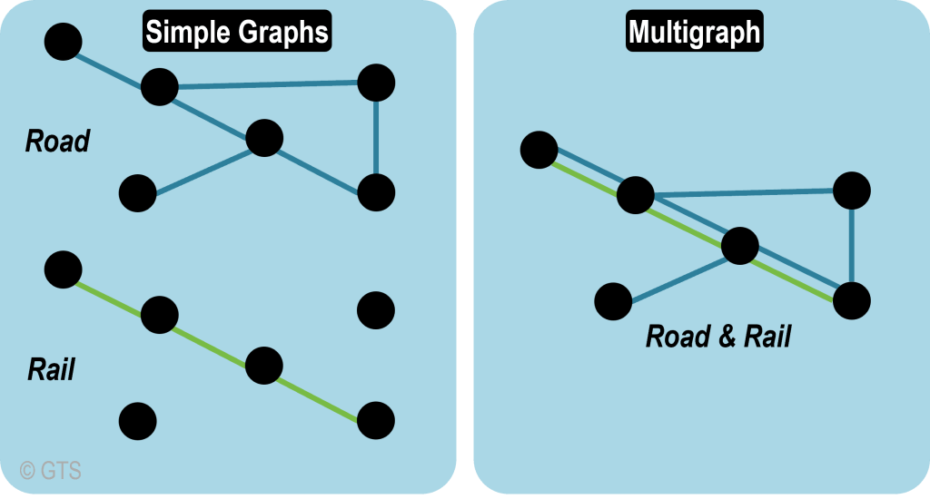

## Weighted Graph

- A graph is considered weighted if it has numbers associated with edges. Weighted graphs are particularly useful for applications such as mapping between two locations, to take into consideration traﬃc, distance, time, etc.
- Here is an example weighted graph of airline flights, with the weights representing the miles between airports

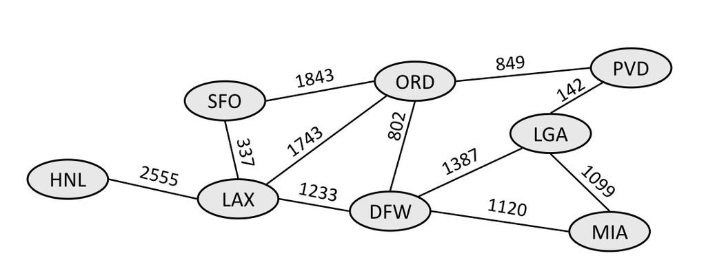

## Direct vs. Undirected

- if the vertices represent people at a party, and there is an edge between two people if they shake hands, then this graph is undirected because any person A can shake hands with a person B only if B also shakes hands with A.
- if an edge from a person A to a person B means that A owes money to B, then this graph is directed, because owing money is not necessarily reciprocated.

## Undirected Graph

Any person can shake hands with another person only if that other person also shakes hands with the first person.

[figure not shown]

## Direct Graph

if an edge from a person A to a person B means that A owes money to B, then this graph is directed, because owing money is not necessarily reciprocated.

[figure not shown]

# How can we represent a graph?

## Graph Representation

- Adjacency Matrix
- Adjacency List
- Edge List

## Adjacency Matrix

```
0 0 0 0 0 0 0
0 1 1 0 0 1 0
0 1 0 1 0 1 0
0 0 1 0 1 0 0
0 0 0 1 0 1 1
0 1 1 0 1 0 0
0 0 0 0 1 0 0
```

[figure not shown]

## Adjacency Matrix

You can use an adjacency Matrix for direct graphs, indicating that either

- There is an edge from i to j
- There is an edge from j to i

## Adjacency List

An adjacency list is a graph representation where each for each vertex you store a list of neighbouring verticies.

```
0 -> {}
1 -> {1, 2, 5}
2 -> {1, 5, 3}
3 -> {2, 4,}
4 -> {3, 5, 6}
5 -> {1, 2, 4}
6 -> {4}
```

There are diﬀerent ways to do this implementation: with hash tables, arrays, lists, with OOP and vertex and edge classes.

## Adjacency List

```
0 -> {}
1 -> {1, 2, 5}
2 -> {1, 5, 3}
3 -> {2, 4}
4 -> {3, 5, 6}
5 -> {1, 2, 4}
6 -> {4}
```

[figure not shown]

## Adjacency List

```
0 -> {2, 1}
1 -> {3, 4}
2 -> {3}
3 -> {4}
4 -> {}
```

[figure not shown]

## Adjacency Matrix vs Adjacency List

- Adjacency Lists are more space eﬃcient that Adjacency Matrix
- Diﬀerent operations have diﬀerent costs
  - In an adjacency list neighbors of each vertex are listed eﬃciently compared to the “degree” of the vertex
  - In adjacency matrix checking if two nodes are connected is constant time
  - Linear Systems of equations are easier with adjacency Matrix

## Edge List

We can also represent a graph by storing a list of edges.

[[0, 1], [0, 2], [0,3], [1,3], [1,4], [2,3], [3, 4]]

[figure not shown]

go back to course home